# Assignment_1

```python
## Load the Wage CSV dataset

import pandas as pd

wage_data = pd.read_csv("Wage.csv", index_col=0)
wage_data.head(10)
```

|  | year | age | maritl | race | education | region | jobclass | health | health_ins | logwage | wage |
| --- | --- | --- | --- | --- | --- | --- | --- | --- | --- | --- | --- |
| 231655 | 2006 | 18 | 1. Never Married | 1. White | 1. < HS Grad | 2. Middle Atlantic | 1. Industrial | 1. <=Good | 2. No | 4.318063 | 75.043154 |
| 86582 | 2004 | 24 | 1. Never Married | 1. White | 4. College Grad | 2. Middle Atlantic | 2. Information | 2. >=Very Good | 2. No | 4.255273 | 70.476020 |
| 161300 | 2003 | 45 | 2. Married | 1. White | 3. Some College | 2. Middle Atlantic | 1. Industrial | 1. <=Good | 1. Yes | 4.875061 | 130.982177 |
| 155159 | 2003 | 43 | 2. Married | 3. Asian | 4. College Grad | 2. Middle Atlantic | 2. Information | 2. >=Very Good | 1. Yes | 5.041393 | 154.685293 |
| 11443 | 2005 | 50 | 4. Divorced | 1. White | 2. HS Grad | 2. Middle Atlantic | 2. Information | 1. <=Good | 1. Yes | 4.318063 | 75.043154 |
| 376662 | 2008 | 54 | 2. Married | 1. White | 4. College Grad | 2. Middle Atlantic | 2. Information | 2. >=Very Good | 1. Yes | 4.845098 | 127.115744 |
| 450601 | 2009 | 44 | 2. Married | 4. Other | 3. Some College | 2. Middle Atlantic | 1. Industrial | 2. >=Very Good | 1. Yes | 5.133021 | 169.528538 |
| 377954 | 2008 | 30 | 1. Never Married | 3. Asian | 3. Some College | 2. Middle Atlantic | 2. Information | 1. <=Good | 1. Yes | 4.716003 | 111.720849 |
| 228963 | 2006 | 41 | 1. Never Married | 2. Black | 3. Some College | 2. Middle Atlantic | 2. Information | 2. >=Very Good | 1. Yes | 4.778151 | 118.884359 |
| 81404 | 2004 | 52 | 2. Married | 1. White | 2. HS Grad | 2. Middle Atlantic | 2. Information | 2. >=Very Good | 1. Yes | 4.857332 | 128.680488 |

```python
## Display the number of features and thir names

wage_data.shape[1], list(wage_data.columns)
```

```
(11,
 ['year',
  'age',
  'maritl',
  'race',
  'education',
  'region',
  'jobclass',
  'health',
  'health_ins',
  'logwage',
  'wage'])
```

```python
## Delete "lowage" and dsiplay number of eatures and their names again

wage_data = wage_data.drop(columns=["logwage"])
wage_data.shape[1], list(wage_data.columns)
```

```
(10,
 ['year',
  'age',
  'maritl',
  'race',
  'education',
  'region',
  'jobclass',
  'health',
  'health_ins',
  'wage'])
```

```python
## Display the number of data points

wage_data.shape[0]
```

```
3000
```

```python
## Dsiplay the data in a table "subset"

wage_data.head(15)
```

|  | year | age | maritl | race | education | region | jobclass | health | health_ins | wage |
| --- | --- | --- | --- | --- | --- | --- | --- | --- | --- | --- |
| 231655 | 2006 | 18 | 1. Never Married | 1. White | 1. < HS Grad | 2. Middle Atlantic | 1. Industrial | 1. <=Good | 2. No | 75.043154 |
| 86582 | 2004 | 24 | 1. Never Married | 1. White | 4. College Grad | 2. Middle Atlantic | 2. Information | 2. >=Very Good | 2. No | 70.476020 |
| 161300 | 2003 | 45 | 2. Married | 1. White | 3. Some College | 2. Middle Atlantic | 1. Industrial | 1. <=Good | 1. Yes | 130.982177 |
| 155159 | 2003 | 43 | 2. Married | 3. Asian | 4. College Grad | 2. Middle Atlantic | 2. Information | 2. >=Very Good | 1. Yes | 154.685293 |
| 11443 | 2005 | 50 | 4. Divorced | 1. White | 2. HS Grad | 2. Middle Atlantic | 2. Information | 1. <=Good | 1. Yes | 75.043154 |
| 376662 | 2008 | 54 | 2. Married | 1. White | 4. College Grad | 2. Middle Atlantic | 2. Information | 2. >=Very Good | 1. Yes | 127.115744 |
| 450601 | 2009 | 44 | 2. Married | 4. Other | 3. Some College | 2. Middle Atlantic | 1. Industrial | 2. >=Very Good | 1. Yes | 169.528538 |
| 377954 | 2008 | 30 | 1. Never Married | 3. Asian | 3. Some College | 2. Middle Atlantic | 2. Information | 1. <=Good | 1. Yes | 111.720849 |
| 228963 | 2006 | 41 | 1. Never Married | 2. Black | 3. Some College | 2. Middle Atlantic | 2. Information | 2. >=Very Good | 1. Yes | 118.884359 |
| 81404 | 2004 | 52 | 2. Married | 1. White | 2. HS Grad | 2. Middle Atlantic | 2. Information | 2. >=Very Good | 1. Yes | 128.680488 |
| 302778 | 2007 | 45 | 4. Divorced | 1. White | 3. Some College | 2. Middle Atlantic | 2. Information | 1. <=Good | 1. Yes | 117.146817 |
| 305706 | 2007 | 34 | 2. Married | 1. White | 2. HS Grad | 2. Middle Atlantic | 1. Industrial | 2. >=Very Good | 2. No | 81.283253 |
| 8690 | 2005 | 35 | 1. Never Married | 1. White | 2. HS Grad | 2. Middle Atlantic | 2. Information | 2. >=Very Good | 1. Yes | 89.492480 |
| 153561 | 2003 | 39 | 2. Married | 1. White | 4. College Grad | 2. Middle Atlantic | 1. Industrial | 2. >=Very Good | 1. Yes | 134.705375 |
| 449654 | 2009 | 54 | 2. Married | 1. White | 2. HS Grad | 2. Middle Atlantic | 2. Information | 2. >=Very Good | 1. Yes | 134.705375 |

```python
## Statistic summary of the features

import numpy as np
import pandas as pd

for column_name in wage_data.columns:
    print(column_name)
    column_series = wage_data[column_name]

    if pd.api.types.is_numeric_dtype(column_series):
        numeric_values = column_series.dropna().to_numpy()
        q1, med, q3 = np.percentile(numeric_values, [25, 50, 75])

        print(f"   Min.   : {numeric_values.min():.6g}")
        print(f"   1st Qu.: {q1:.6g}")
        print(f"   Median : {med:.6g}")
        print(f"   Mean   : {numeric_values.mean():.6g}")
        print(f"   3rd Qu.: {q3:.6g}")
        print(f"   Max.   : {numeric_values.max():.6g}")
    else:
        counts = column_series.value_counts(dropna=False)
        for level, count in counts.items():
            print(f"   {level}: {count}")

    print()
```

```
year
   Min.   : 2003
   1st Qu.: 2004
   Median : 2006
   Mean   : 2005.79
   3rd Qu.: 2008
   Max.   : 2009

age
   Min.   : 18
   1st Qu.: 33.75
   Median : 42
   Mean   : 42.4147
   3rd Qu.: 51
   Max.   : 80

maritl
   2. Married: 2074
   1. Never Married: 648
   4. Divorced: 204
   5. Separated: 55
   3. Widowed: 19

race
   1. White: 2480
   2. Black: 293
   3. Asian: 190
   4. Other: 37

education
   2. HS Grad: 971
   4. College Grad: 685
   3. Some College: 650
   5. Advanced Degree: 426
   1. < HS Grad: 268

region
   2. Middle Atlantic: 3000

jobclass
   1. Industrial: 1544
   2. Information: 1456

health
   2. >=Very Good: 2142
   1. <=Good: 858

health_ins
   1. Yes: 2083
   2. No: 917

wage
   Min.   : 20.0855
   1st Qu.: 85.3839
   Median : 104.922
   Mean   : 111.704
   3rd Qu.: 128.68
   Max.   : 318.342
```

```python
## Numerical features

import matplotlib.pyplot as plt
from scipy import stats
```

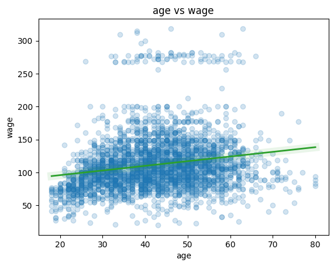

```python
## Age numerical feature
## Plot the feature against the lable values
x_age = wage_data["age"]
y_wage = wage_data["wage"]

plt.figure()
plt.scatter(x_age, y_wage, alpha=0.2)

slope, intercept, _, _, _, = stats.linregress(x_age, y_wage)
x_line = np.linspace(x_age.min(), x_age.max(), 300)
y_line = intercept + slope * x_line

plt.plot(x_line, y_line, color="C2", linewidth=10, alpha=0.1)
plt.plot(x_line, y_line, color="C2", linewidth=2, alpha=1.0)

plt.xlabel("age")
plt.ylabel("wage")
plt.title("age vs wage")
plt.show()
```

```
Shapiro age: W=0.99106, p=9.42e-13
Shapiro wage: W=0.87957, p=2.46e-43
```

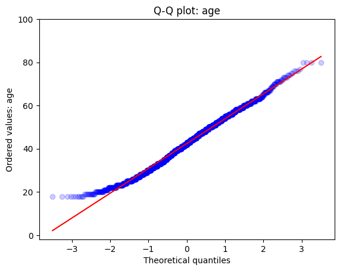

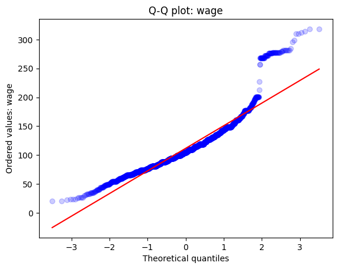

```python
## Age numerical feature
## Test the normality of the feature and label values

shapiro_age_W, shapiro_age_p = stats.shapiro(x_age)
shapiro_wage_W, shapiro_wage_p = stats.shapiro(y_wage)

print(f"Shapiro age: W={shapiro_age_W:.5f}, p={shapiro_age_p:.3g}")
print(f"Shapiro wage: W={shapiro_wage_W:.5f}, p={shapiro_wage_p:.3g}")

plt.figure()
stats.probplot(x_age, dist="norm", plot=plt)
plt.gca().lines[0].set_alpha(0.2)
plt.ylim(None, 100)
plt.ylabel("Ordered values: age")
plt.title("Q-Q plot: age")
plt.show()

plt.figure()
stats.probplot(y_wage.dropna(), dist="norm", plot=plt)
plt.gca().lines[0].set_alpha(0.2)
plt.ylabel("Ordered values: wage")
plt.title("Q-Q plot: wage")
plt.show()
```

```python
## The Pearson correlation

r_age, p_age = stats.pearsonr(wage_data["age"], wage_data["wage"])
print(f"Pearson (age vs wage): r={r_age:.7f}, p={p_age:.7g}")
```

```
Pearson (age vs wage): r=0.1956372, p=2.900778e-27
```

Interpretation (age): Weak positive relationship, Pearson correlation is significant (small p-value), but the effect is not strong "weak 0.20".

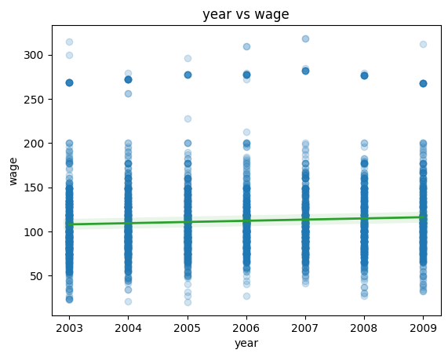

```python
## Year numerical feature

x_year = wage_data["year"]
y_wage = wage_data["wage"]

plt.figure()
plt.scatter(x_year, y_wage, alpha=0.2)

slope, intercept, _, _, _ = stats.linregress(x_year, y_wage)
x_line = np.linspace(x_year.min(), x_year.max(), 300)
y_line = intercept + slope * x_line

plt.plot(x_line, y_line, color="C2", linewidth=10, alpha=0.1)
plt.plot(x_line, y_line, color="C2", linewidth=2, alpha=1.0)

plt.xlabel("year")
plt.ylabel("wage")
plt.title("year vs wage")
plt.show()
```

```
Shapiro-Wilk year: W=0.911128, p-value=9.24729e-39
Shapiro-Wilk wage: W=0.879574, p-value=2.46307e-43
```

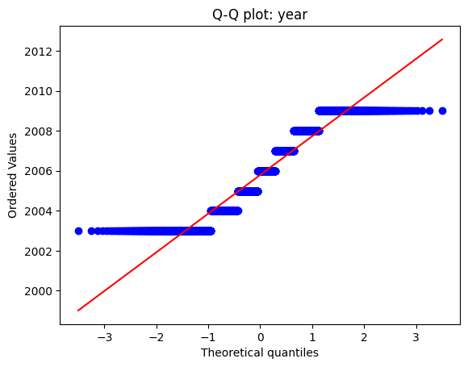

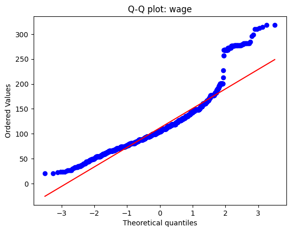

```python
## Test the normality of the feature and label values

W_year, p_year_norm = stats.shapiro(x_year)
W_wage, p_wage_norm = stats.shapiro(y_wage)

print(f"Shapiro-Wilk year: W={W_year:.6f}, p-value={p_year_norm:.6g}")
print(f"Shapiro-Wilk wage: W={W_wage:.6f}, p-value={p_wage_norm:.6g}")

plt.figure()
stats.probplot(x_year, dist="norm", plot=plt)
plt.title("Q-Q plot: year")
plt.show()

plt.figure()
stats.probplot(y_wage, dist="norm", plot=plt)
plt.title("Q-Q plot: wage")
plt.show()
```

```python
## The Pearson correlation

r_year, p_year = stats.pearsonr(wage_data["year"], wage_data["wage"])
print(f"Pearson (year vs wage): r={r_year:.7f}, p={p_year:.7g}")
```

```
Pearson (year vs wage): r=0.0655443, p=0.0003276778
```

Interpretation (year): Very weak relationship. Pearson correlation can be significant due to many samples, but the effect is very weak.

```python
## the non-numerical features

np.random.seed(0)
```

```python
## maritl non numerical

feature_col = "maritl"
levels = wage_data[feature_col].dropna().unique().tolist()
print(levels)
```

```
['1. Never Married', '2. Married', '4. Divorced', '3. Widowed', '5. Separated']
```

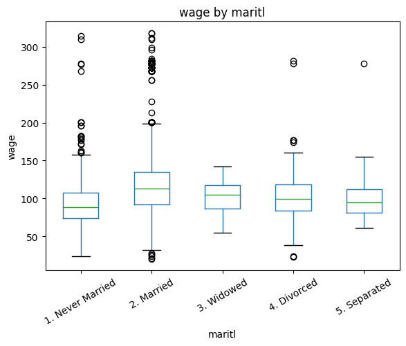

```python
## Plotting "box plot"

plt.figure(figsize=(10, 4))
wage_data.boxplot(column="wage", by=feature_col, grid=False, rot=30)
plt.title(f"{"wage"} by {feature_col}")
plt.suptitle("")
plt.xlabel(feature_col)
plt.ylabel("wage")
plt.show()
```

```python
#ANOVA

groups = [wage_data.loc[wage_data[feature_col] == lvl, "wage"].dropna() for lvl in levels]
F_value, p_value = stats.f_oneway(*groups)
print(f"ANOVA wage ~ {feature_col}: F={F_value:.3f}, p-value={p_value:.6g}")
```

```
ANOVA wage ~ maritl: F=55.960, p-value=1.4012e-45
```

Interpretation (maritl): Wage differs between marital status groups, ANOVA p value showing the group means are not all equal.

```python
#Race non numerical
feature_col = "race"
levels = wage_data[feature_col].dropna().unique().tolist()
print(levels)
```

```
['1. White', '3. Asian', '4. Other', '2. Black']
```

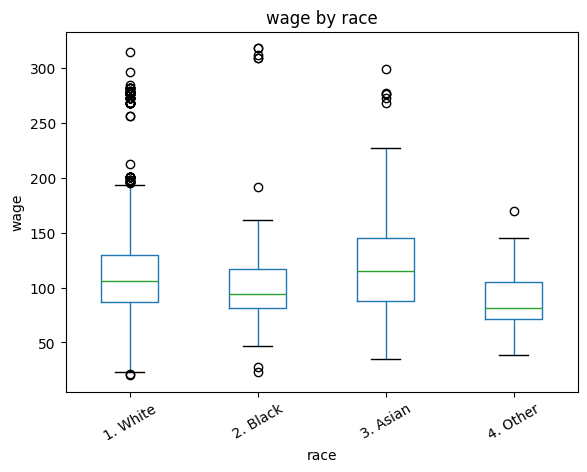

```python
## Plotting "box plot"
plt.figure(figsize=(10, 4))
wage_data.boxplot(column="wage", by=feature_col, grid=False, rot=30)
plt.title(f"{"wage"} by {feature_col}")
plt.suptitle("")
plt.xlabel(feature_col)
plt.ylabel("wage")
plt.show()
```

```python
## ANOVA

groups = [wage_data.loc[wage_data[feature_col] == lvl, "wage"].dropna() for lvl in levels]
F_value, p_value = stats.f_oneway(*groups)
print(f"ANOVA wage ~ {feature_col}: F={F_value:.3f}, p-value={p_value:.6g}")
```

```
ANOVA wage ~ race: F=12.237, p-value=5.89023e-08
```

Interpretation (race): Boxplots show differences between groups. ANOVA p value indicates mean wages differ by race group.

```python
## Education non numerical

feature_col = "education"
levels = wage_data[feature_col].dropna().unique().tolist()
print(levels)
```

```
['1. < HS Grad', '4. College Grad', '3. Some College', '2. HS Grad', '5. Advanced Degree']
```

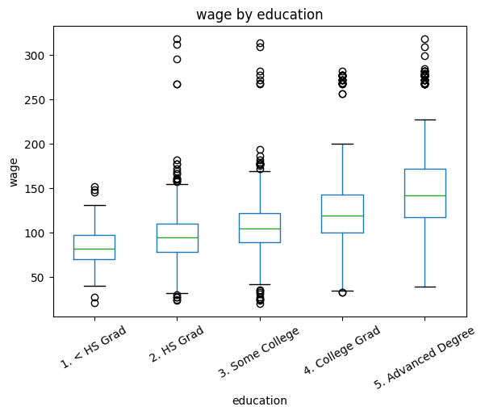

```python
## Plotting "box plot"
plt.figure(figsize=(10, 4))
wage_data.boxplot(column="wage", by=feature_col, grid=False, rot=30)
plt.title(f"{"wage"} by {feature_col}")
plt.suptitle("")
plt.xlabel(feature_col)
plt.ylabel("wage")
plt.show()
```

```python
## ANOVA
groups = [wage_data.loc[wage_data[feature_col] == lvl, "wage"].dropna() for lvl in levels]
F_value, p_value = stats.f_oneway(*groups)
print(f"ANOVA wage ~ {feature_col}: F={F_value:.3f}, p-value={p_value:.6g}")
```

```
ANOVA wage ~ education: F=229.806, p-value=2.91593e-172
```

Interpretation (education): Clear wage differences across education levels. ANOVA p value shows the group means are not equal.

```python
## Region non numerical

feature_col = "region"
levels = wage_data[feature_col].dropna().unique().tolist()
print(levels)
```

```
['2. Middle Atlantic']
```

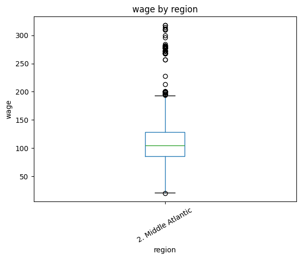

```python
## Plotting "box plot"
plt.figure(figsize=(10, 4))
wage_data.boxplot(column="wage", by=feature_col, grid=False, rot=30)
plt.title(f"{"wage"} by {feature_col}")
plt.suptitle("")
plt.xlabel(feature_col)
plt.ylabel("wage")
plt.show()
```

```python
## ANOVA

# SIGNLE VALUE "NOT APPLICABLE".
```

Interpretation (region): Only one region level appears in this dataset, so can't compare groups with ANOVA.

```python
## JOBCLASS non numerical

feature_col = "jobclass"
levels = wage_data[feature_col].dropna().unique().tolist()
print (levels)
```

```
['1. Industrial', '2. Information']
```

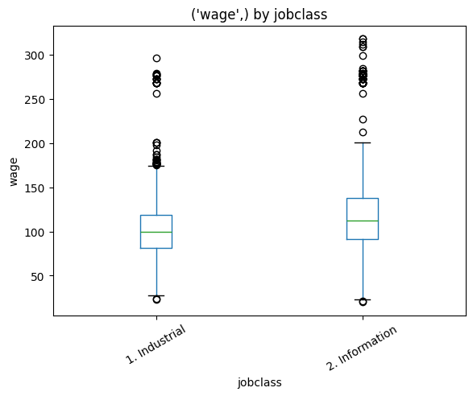

```python
## Plotting "box plot"
plt.figure(figsize=(10, 4))
wage_data.boxplot(column="wage", by=feature_col, grid=False, rot=30)
plt.title(f"{"wage",} by {feature_col}")
plt.suptitle("")
plt.xlabel(feature_col)
plt.ylabel("wage",)
plt.show()
```

```python
## ANOVA
groups = [wage_data.loc[wage_data[feature_col] == lvl, "wage"].dropna() for lvl in levels]
F_value, p_value = stats.f_oneway(*groups)
print(f"ANOVA wage ~ {feature_col}: F={F_value:.3f}, p-value={p_value:.6g}")
```

```
ANOVA wage ~ jobclass: F=134.073, p-value=2.30819e-30
```

Interpretation (jobclass): Wage differs between job classes. ANOVA p value shows the mean wages are different.

```python
## Health non numerical

feature_col = "health"
levels = wage_data[feature_col].dropna().unique().tolist()
print(levels)
```

```
['1. <=Good', '2. >=Very Good']
```

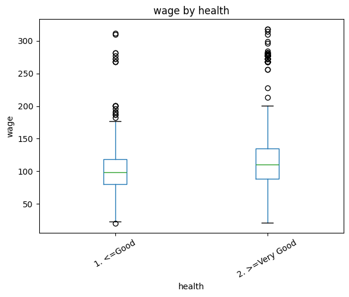

```python
## Plotting "box plot"

plt.figure(figsize=(10, 4))
wage_data.boxplot(column="wage", by=feature_col, grid=False, rot=30)
plt.title(f"{"wage"} by {feature_col}")
plt.suptitle("")
plt.xlabel(feature_col)
plt.ylabel("wage")
plt.show()
```

```python
## ANOVA

groups = [wage_data.loc[wage_data[feature_col] == lvl, "wage"].dropna() for lvl in levels]
F_value, p_value = stats.f_oneway(*groups)
print(f"ANOVA wage ~ {feature_col}: F={F_value:.3f}, p-value={p_value:.6g}")
```

```
ANOVA wage ~ health: F=71.227, p-value=4.8864e-17
```

Interpretation (health): Boxplots suggest group differences. ANOVA p value states mean wages differ by health group.

```python
## Health_ins non numerical

feature_col = "health_ins"
levels = wage_data[feature_col].dropna().unique().tolist()
print(levels)
```

```
['2. No', '1. Yes']
```

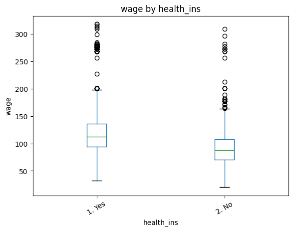

```python
## Plotting "boxplot"

plt.figure(figsize=(10, 4))
wage_data.boxplot(column="wage", by=feature_col, grid=False, rot=30)
plt.title(f"{"wage"} by {feature_col}")
plt.suptitle("")
plt.xlabel(feature_col)
plt.ylabel("wage")
plt.show()
```

```python
## ANOVA
groups = [wage_data.loc[wage_data[feature_col] == lvl, "wage"].dropna() for lvl in levels]
F_value, p_value = stats.f_oneway(*groups)
print(f"ANOVA wage ~ {feature_col}: F={F_value:.3f}, p-value={p_value:.6g}")
```

[output not shown]